# Addressing the Business Question

Introduce the problem and define key terms

Weddings are generally regarded as expensive; according to a survey published last year by The Knot, the national average cost of a wedding was $30,000. (Stations, 2023)Additionally, people think sustainable products as lower quality, less aesthetically pleasing, and more expensive. (White, 2023) Therefore, we aim to determine if we can provide cost-effective weddings to customers.

1. Wedding Vendors: These include a wide range of businesses crucial to the wedding ceremony or celebration, such as venues, catering, florists, photography, and more. Our Wedding database comprises ten departments, all essential for the smooth execution of a wedding event.
2. Sustainable: In the most broad way, sustainability refers to the ability to continuously maintain or support a process over time. In business and policy contexts, sustainability seeks to prevent the depletion of natural or physical resources in order to ensure their long-term availability. In this case, each vendor is labeled with vendor_sustainable, with 'yes' representing 1 and 'no' representing 0. (Mollenkamp, 2023)
3. Cost-effective: It refers to good value for the money spent. (Cost-effective, 2023)

Answer the business question

We compared the cost-effectiveness of service providers with and without sustainable practices using the Student's t-test on the wedding database. Because the p-value (9.952837709511204e-05) was less than a significance level of 0.05. Hence, the null hypothesis was rejected, indicating a statistically significant difference in cost-effectiveness. The findings show that in our sample, vendors who practice sustainable practices have a significant cost-effectiveness advantage. This implies that investing in sustainability may benefit vendors' cost-effectiveness.

In summary, the data indicate that a significant portion of vendors (around 55%) are recognized as sustainable, with significant variation. The average vendor rating is 37.85 (out of a possible 50) with a standard deviation of 19.74. The 1586 average price, along with a higher standard deviation. Also, the mean of cost-effectiveness is 2.29. This comprehensive overview reveals the central tendencies, distribution, and variability of sustainability, ratings, price, and cost-effectiveness, laying the foundations for further research and analysis.

```python
import matplotlib.pyplot as plt
import seaborn as sns
import pandas as pd
```

```python
#All Vendor sheet

file = "/Users/vivi/Desktop/all.xlsx"
wedding = pd.read_excel(io = file,
                         sheet_name = 0,
                         header = 0)
wedding.describe().round(decimals = 2)
```

|  | vendor_sustainable | vendor_rating | price_unit | price_ce |
| --- | --- | --- | --- | --- |
| count | 695.00 | 695.00 | 695.00 | 695.00 |
| mean | 0.55 | 37.85 | 1586.12 | 2.29 |
| std | 0.50 | 19.74 | 4183.57 | 1.09 |
| min | 0.00 | 0.00 | 0.00 | 0.00 |
| 25% | 0.00 | 40.00 | 80.00 | 1.00 |
| 50% | 1.00 | 49.00 | 200.00 | 2.00 |
| 75% | 1.00 | 50.00 | 756.50 | 3.00 |
| max | 1.00 | 50.00 | 32000.00 | 4.00 |

```python
from scipy.stats import ttest_ind

# Divide wedding database into two categories: vendors who use sustainable practices and those who don't.
sustainable_group = wedding[wedding['vendor_sustainable'] == 1]['price_ce']
non_sustainable_group = wedding[wedding['vendor_sustainable'] == 0]['price_ce']

# ttest
t_statistic, p_value = ttest_ind(sustainable_group, non_sustainable_group)

# result
print(f"T-statistic: {t_statistic}")
print(f"P-value: {p_value}")

# Significance level of 0.05
alpha = 0.05
if p_value < alpha:
    print("""Cost-effectiveness differences among vendors with sustainable practices were
found to be statistically significant.""")
else:
    print("""Cost-effectiveness differences observed among vendors
with sustainable practices are not statistically significant.""")
```

```
T-statistic: 3.9145243451532576
P-value: 9.952837709511204e-05
Cost-effectiveness differences among vendors with sustainable practices were
found to be statistically significant.
```

Use markdown to explain the rest of analysis

The first section has two plots titled "Distribution of Cost Effectiveness for Vendors", which demonstrates how sustainable and non-sustainable suppliers vary with regard to price-cost effectiveness. We can see in the non-sustainable suppliers' table that price cost-effective label 1 is the most common, while the sustainable suppliers' table shows that price cost-effective label 3 is the most prevalent. Moving to the second section is a scatterplot, which takes sustainability vendors into consideration, and demonstrates the relationship between price units and cost-effective prices. Information with respect to the relationship between sustainability and cost-effectiveness can be discovered within the data points. The scatterplot illustrates the pricing unit and cost-effectiveness of two types of suppliers and suggests whether or not there is a correlation with sustainable vendors. The third section features a box plot that shows the price distribution of wedding products across vendor divisions and sustainability levels. Each box represents the middle 50% of the price range, with different colors indicating suppliers who are sustainable and those who are not. This plot makes it possible to compare different departments and sustainability levels, which makes it easier to analyze price variations and possible effects of sustainability on prices. In conclusion, these graphs provide an extensive overview of the relationship between supplier sustainability, price, and cost-effectiveness. The scatterplot helps to understand trends, whereas the box plot reveals price differences across sectors and levels of sustainability. These visualizations are effective tools for analyzing and comparing the complex interactions of sustainability, pricing, and cost-effectiveness in the wedding product market.

```python
#Non_Sustainable Vendor sheet

file = "/Users/vivi/Desktop/nonsus.xlsx"

# Load data
wedding_ns = pd.read_excel(io = file)
wedding_ns.head(n=10)
```

|  | vendor_id | vendor_depart | vendor_location | vendor_sustainable | vendor_rating | product_id | product_name | price_unit | unit_vol | price_ce |
| --- | --- | --- | --- | --- | --- | --- | --- | --- | --- | --- |
| 0 | att_01 | dress and attire | san francisco | 0 | 0 | prod_805 | dress - belobed by casablance bridal | 1750.0 | 1 per person | 4 |
| 1 | att_02 | dress and attire | online | 0 | 0 | prod_806 | dress - madison james by allure bridals | 1750.0 | 1 per person | 4 |
| 2 | att_02 | dress and attire | online | 0 | 0 | prod_807 | dress - disney fairy tale weddings | 2250.0 | 1 per person | 4 |
| 3 | att_02 | dress and attire | online | 0 | 0 | prod_826 | dress - allure bridesmaids | 225.0 | 1 per person | 2 |
| 4 | att_03 | dress and attire | online | 0 | 0 | prod_808 | dress - stacees amy wedding dress | 616.0 | 1 per person | 4 |
| 5 | att_03 | dress and attire | online | 0 | 0 | prod_809 | dress - stacees isabella wedding dress | 537.0 | 1 per person | 4 |
| 6 | att_03 | dress and attire | online | 0 | 0 | prod_810 | dress - stacees annie wedding dress | 417.0 | 1 per person | 3 |
| 7 | att_03 | dress and attire | online | 0 | 0 | prod_811 | dress - stacees elaine wedding dress | 537.0 | 1 per person | 4 |
| 8 | att_03 | dress and attire | online | 0 | 0 | prod_812 | dress - luxury lace long sleeves slit wedding ... | 350.0 | 1 per person | 3 |
| 9 | att_04 | dress and attire | online | 0 | 0 | prod_813 | dress - luxury lace off-the-shoulder wedding d... | 320.0 | 1 per person | 2 |

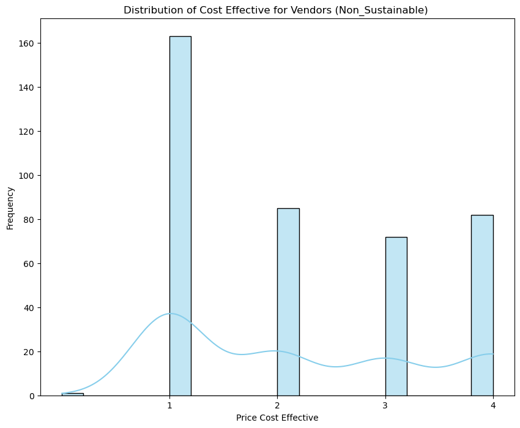

```python
#Non_Sustainable Vendor

# specifying plot size
fig, ax = plt.subplots( figsize = (10 , 8) )

# histogram for price_ce
sns.histplot(wedding_ns['price_ce'], kde=True, color='skyblue', bins=20)

#Set x-axis ticks to display with price_ce integer values
ax.xaxis.set_ticks([1, 2, 3, 4])

plt.title('Distribution of Cost Effective for Vendors (Non_Sustainable) ')
plt.xlabel('Price Cost Effective')
plt.ylabel('Frequency')
plt.show()
```

```python
#Sustainable Vendor sheet
file = "/Users/vivi/Desktop/sus.xlsx"


wedding_su = pd.read_excel(io = file)
wedding_su.head(n=10)
```

|  | vendor_id | vendor_depart | vendor_location | vendor_sustainable | vendor_rating | product_id | product_name | price_unit | unit_vol | price_ce |
| --- | --- | --- | --- | --- | --- | --- | --- | --- | --- | --- |
| 0 | att_06 | dress and attire | online | 1 | 0 | prod_821 | dress - trumpet scoop court train lace wedding... | 244.00 | 1 per person | 2 |
| 1 | att_06 | dress and attire | online | 1 | 0 | prod_822 | dress - princess v-neck court train tulle wedd... | 404.00 | 1 per person | 3 |
| 2 | att_06 | dress and attire | online | 1 | 0 | prod_823 | dress - mermaid v-neck court train lace weddin... | 329.00 | 1 per person | 2 |
| 3 | att_06 | dress and attire | online | 1 | 0 | prod_827 | dress - birdy grey | 75.00 | 1 per person | 1 |
| 4 | att_09 | dress and attire | san francisco | 1 | 0 | prod_830 | dress - scarf neck one-shoulder stretch satin ... | 349.00 | 1 per person | 3 |
| 5 | att_09 | dress and attire | san francisco | 1 | 0 | prod_831 | dress - long puff sleeve v-neck trumpet gown | 275.00 | 1 per person | 2 |
| 6 | att_11 | dress and attire | online | 1 | 0 | prod_833 | dress - kennedy blue | 125.00 | 1 per person | 1 |
| 7 | att_14 | dress and attire | san francisco | 1 | 0 | prod_840 | tuxedo - Pronto Uomo Platinum Modern Fit Suit ... | 249.99 | 1 per person | 1 |
| 8 | att_14 | dress and attire | san francisco | 1 | 0 | prod_841 | suit - JOE Joseph Abboud Slim Fit Suit Separat... | 249.99 | 1 per person | 1 |
| 9 | att_15 | dress and attire | san francisco | 1 | 0 | prod_842 | suit - dark navy tonal plaid stretch wool suit | 1325.00 | 1 per person | 4 |

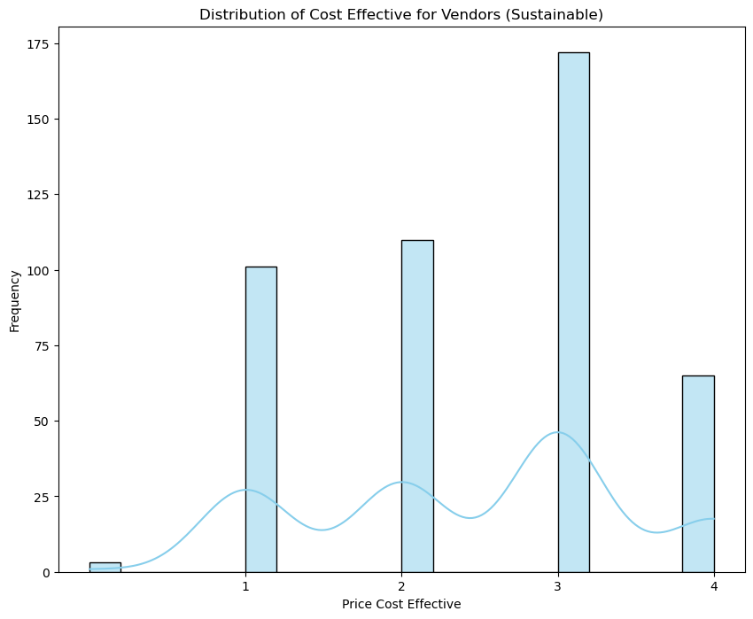

```python
#Sustainable Vendor

# specifying plot size
fig, ax = plt.subplots( figsize = (10 , 8) )

# histogram for price_ce
sns.histplot(wedding_su['price_ce'], kde=True, color='skyblue', bins=20)

# Set x-axis ticks to display with price_ce integer values
ax.xaxis.set_ticks([1, 2, 3, 4])

plt.title('Distribution of Cost Effective for Vendors (Sustainable)')
plt.xlabel('Price Cost Effective')
plt.ylabel('Frequency')
plt.show()
```

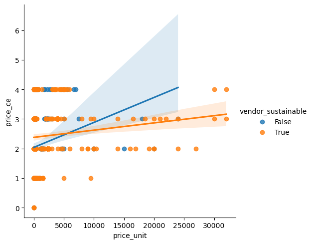

```python
#Scatterplot

# instantiating a scatter plot for price_unit and price_ce, show correlation for vendor_sustainable
sns.lmplot(x='price_unit', y='price_ce', hue='vendor_sustainable', data= wedding)


plt.show()
```

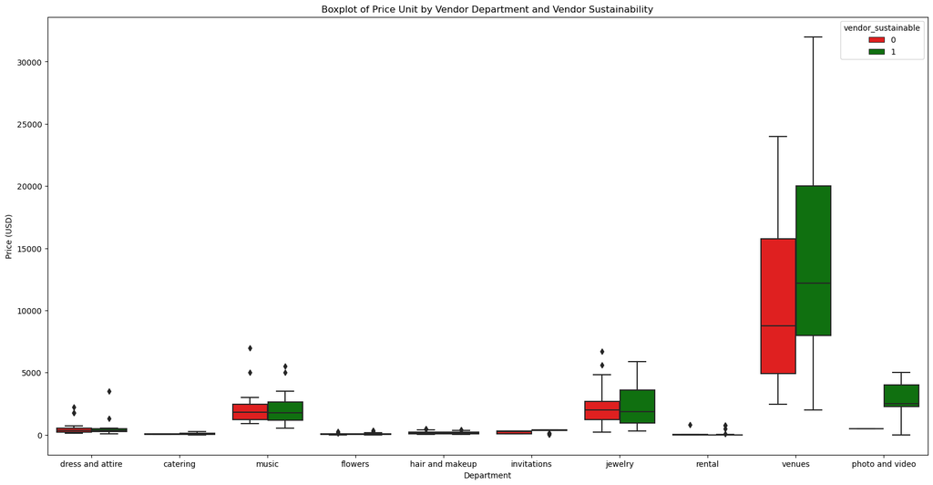

```python
# Plot boxplot

# specifying plot size

plt.figure(figsize=(20, 10))

# instantiating a scatter plot for price_unit and each department, and show with vendor sustainable or not
sns.boxplot(x='vendor_depart', y='price_unit', data=wedding, hue='vendor_sustainable', palette={True: 'g', False: 'r'})

plt.title('Boxplot of Price Unit by Vendor Department and Vendor Sustainability')
plt.xlabel('Department')
plt.ylabel('Price (USD)')

plt.show()
```

Two actionable insights

1.Strategic Pricing for Sustainable Vendors

According to the 'Distribution of Cost Effectiveness for Vendors,' exploring vendors offering sustainable products with a price cost-effective range between 2-3 can enhance profitability and meet customer preferences for sustainability. The analysis indicates a statistically significant cost-effectiveness advantage for vendors with sustainable practices. It is advised to use a strategic pricing plan for sustainable vendors in order to take advantage of this. Competitive pricing may be possible while maintaining profitability thanks to cost savings or efficiency gains from sustainable practices. According to a Harvard Business Review study, businesses that accept sustainability usually exceed their competitors, showing possible advantages when it comes to of operational effectiveness and market positioning (Whelan, 2017).

2. Explore more vendors with Sustainable Practices

With approximately 55% of vendors identified as sustainable, there's a significant market presence for sustainable wedding product providers. Giving use of this, the company should devise a marketing strategy emphasizing vendor sustainability. According to a 2020 McKinsey US consumer sentiment survey, over 60% of respondents are willing to pay more for products with sustainable packaging. NielsenIQ's recent study revealed that 78% of US consumers prioritize a sustainable lifestyle. (Am et al., 2023) A sustainability-focused marketing campaign could attract environmentally-conscious consumers, fostering brand loyalty. The Boxplot analysis suggests exploring more vendors for each department, enabling the provision of diverse products to customers. This approach is crucial in determining a strategic pricing strategy.

Reference List:

Am, J. B., Doshi, V., Noble, S., & Malik, A. (2023, February 6). Consumers care about sustainability—and back it up with their wallets. McKinsey & Company. https://www.mckinsey.com/industries/consumer-packaged-goods/our-insights/consumers-care-about-sustainability-and-back-it-up-with-their-wallets cost-effective. (2023). https://dictionary.cambridge.org/us/dictionary/english/cost-effective Mollenkamp, D. T. (2023, April 8). What is Sustainability? How Sustainabilities Work, Benefits, and Example. Investopedia. https://www.investopedia.com/terms/s/sustainability.asp seaborn.boxplot — seaborn 0.13.0 documentation. (n.d.). https://seaborn.pydata.org/generated/seaborn.boxplot.html Stations, F. T. (2023, August 23). Survey: Gen Z, millennial couples say it’s too expensive to get married. FOX 4 News Dallas-Fort Worth. https://www.fox4news.com/news/survey-gen-z-millennial-couples-too-expensive-married Statistical functions (scipy.stats) — SciPy v1.11.4 Manual. (n.d.). https://docs.scipy.org/doc/scipy/reference/stats.html Whelan, T. (2017, June 1). The Comprehensive Business Case for Sustainability. Harvard Business Review. https://hbr.org/2016/10/the-comprehensive-business-case-for-sustainability White, K. (2023, April 5). The Elusive Green Consumer. Harvard Business Review. https://hbr.org/2019/07/the-elusive-green-consumer